# Regression_Project_Final

Aaron Goletz, Alex Aubrey, Malini Senthilkumar, Angela Gaetano

December 7, 2017

# 1) An examination of the distributions of the variables

```r
comm_prop <- read.csv("comm_prop.csv", header=TRUE)
comm_prop$W2MiDT <- factor(comm_prop$W2MiDT, labels = c("No", "Yes"))

kable(head(comm_prop), format = "html", align='c', caption = "Example of Data") #Head function will return the FIRST 6 rows of the dataset
```

Example of Data

| RentRate | Age | OperExp | VacRate | SqFt | Taxes | W2MiDT |
| --- | --- | --- | --- | --- | --- | --- |
| 13.5 | 1 | 5.02 | 0.14 | 123000 | 2.21 | No |
| 12.0 | 14 | 8.19 | 0.27 | 104079 | 1.87 | No |
| 10.5 | 16 | 3.00 | 0.00 | 39998 | 0.72 | No |
| 15.0 | 4 | 10.70 | 0.05 | 57112 | 1.03 | No |
| 14.0 | 11 | 8.97 | 0.07 | 60000 | 1.08 | No |
| 10.5 | 15 | 9.45 | 0.24 | 101385 | 1.82 | No |

```r
summary(comm_prop) #Summary function returns a compact analysis of the dataset
```

```
##     RentRate          Age           OperExp          VacRate
##  Min.   :10.50   Min.   : 0.00   Min.   : 3.000   Min.   :0.0000
##  1st Qu.:14.00   1st Qu.: 2.00   1st Qu.: 7.997   1st Qu.:0.0000
##  Median :15.00   Median : 4.00   Median :10.370   Median :0.0400
##  Mean   :15.13   Mean   : 8.01   Mean   : 9.658   Mean   :0.0801
##  3rd Qu.:16.50   3rd Qu.:15.00   3rd Qu.:11.660   3rd Qu.:0.0925
##  Max.   :19.25   Max.   :20.00   Max.   :14.620   Max.   :0.7300
##       SqFt            Taxes       W2MiDT
##  Min.   : 27000   Min.   :0.490   No :64
##  1st Qu.: 73141   1st Qu.:1.315   Yes:36
##  Median :129614   Median :2.330
##  Mean   :166101   Mean   :2.990
##  3rd Qu.:244547   3rd Qu.:4.402
##  Max.   :484290   Max.   :8.720
```

**Observations**: The sample Data and Summary provide a sense of the data. Just by looking at the brief summary, we observe that a few variables like SqFt and Taxes have a higher mean than their medians. This indicates the variables are probably right-skewed. We will explore the distributions further with histogram plots.

**Variables are :**  
RentRate - Continuous Variable  
Age - Continuous Variable  
OperExp - Continuous Variable  
VacRate - Continuous Variable  
SqFt - Continuous Variable  
Taxes - Continuous Variable W2MiDT - Categorical Variable

## Histograms for distribution visualization

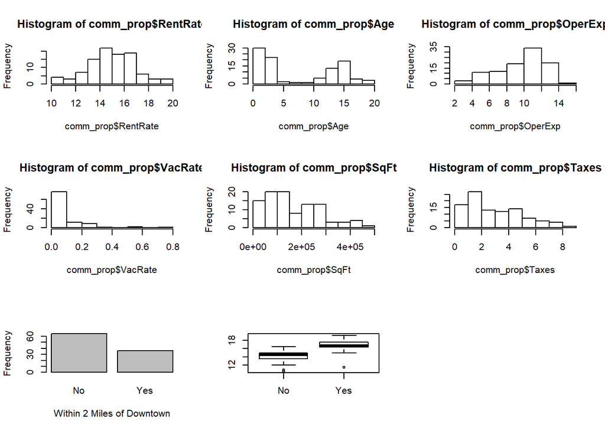

**Observations**: Histograms help us better understand the distribution of continuous variables. Above, we have plotted all continuous variables into histograms and have created a bar plot and boxplot for categorical variables.

**We noticed the following:**  
Rental Rate - looks normally distributed  
Age - appears bimodal. Building construction occurred more frequently about 15 years ago and within the last few years.  
OperExp - contains a slight amount of left/negative skewness  
VacRate - contains strong Right/positive skewness  
SqFt - contain a slight amount of right skewness  
Taxes - contain a slight amount of right skewness  
W2MiDTNo - has a higher frequency  
* The boxplot indicates that the rental rates are higher when the building is within two miles of downtown.

# 2) An examination of the correlations for all continuous variables

**Correlation Matrix with scatterplots and correlation coefficients**

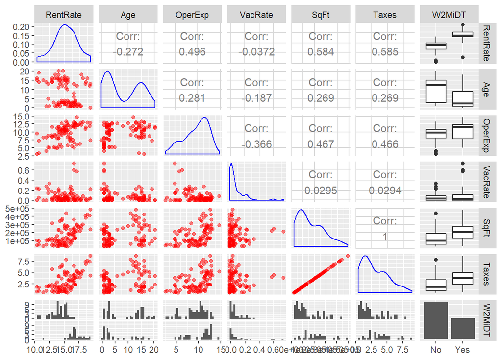

```r
ggpairs(comm_prop[,1:7] ,
        lower = list(continuous = wrap("points", color = "red", alpha = 0.5)),
        diag = list(continuous = wrap("densityDiag",  color = "blue", alpha = 0.5)))
```

**Observations:**  
SqFt and Taxes - have a perfect correlation of 1.00.  
RentRate and OperExp - have a moderate positive correlation.  
RentRate and SqFt - have a strong positive correlation.  
RentRate and Taxes - share the same correlation as of .584.

**Other correlations to note are:** VacRate and OperExp - a negative correlation of -.366  
Age and OperExp - a very small correlation  
Age and RentRate - a very small negative correlation

# 3) The identification and evaluation of a suitable regression model for predicting rental rates

## a) Manual Iteration

### Fit Full Model

```r
m <- lm(RentRate ~ ., data=comm_prop)
summary(m)
```

```
##
## Call:
## lm(formula = RentRate ~ ., data = comm_prop)
##
## Residuals:
##      Min       1Q   Median       3Q      Max
## -2.65450 -0.59760 -0.02213  0.65394  2.57988
##
## Coefficients:
##               Estimate Std. Error t value Pr(>|t|)
## (Intercept) 12.2278960  0.4483644  27.272  < 2e-16 ***
## Age         -0.1040412  0.0185484  -5.609 2.08e-07 ***
## OperExp      0.2255069  0.0497984   4.528 1.76e-05 ***
## VacRate     -0.7568956  0.9114326  -0.830    0.408
## SqFt        -0.0005652  0.0007194  -0.786    0.434
## Taxes       31.7633824 39.9476685   0.795    0.429
## W2MiDTYes    1.4434308  0.2586992   5.580 2.36e-07 ***
## ---
## Signif. codes:  0 '***' 0.001 '**' 0.01 '*' 0.05 '.' 0.1 ' ' 1
##
## Residual standard error: 0.9884 on 93 degrees of freedom
## Multiple R-squared:  0.7463, Adjusted R-squared:   0.73
## F-statistic: 45.61 on 6 and 93 DF,  p-value: < 2.2e-16
```

**Observations:** Results show the model’s significant variables are Age, OperExp, and W2MiDT. The Adjusted R-squared value is 0.73, with an F-statistic of 45.61 and a highly significant p-value of <2.2e-16. The model will now be trimmed to remove non-significant variables.

First, VacRate will be dropped due to non-significance (p-value 0.408). In addition, VacRate is unavailable for use as a final predictor due to unavailable data. Also, the variable Taxes will be dropped from the model due to multicolinearity with SqFt (correlation coefficient 1.0) as evidenced by the correlation matrix above. Since Taxes is a result of SqFt, we are dropping Taxes and retained SqFt in our model.

```r
m.1 <- lm(RentRate ~ Age + OperExp + SqFt + W2MiDT, data=comm_prop)
summary(m.1)
```

```
##
## Call:
## lm(formula = RentRate ~ Age + OperExp + SqFt + W2MiDT, data = comm_prop)
##
## Residuals:
##      Min       1Q   Median       3Q      Max
## -2.90483 -0.58081 -0.03454  0.57347  2.54837
##
## Coefficients:
##               Estimate Std. Error t value Pr(>|t|)
## (Intercept)  1.205e+01  3.789e-01  31.797  < 2e-16 ***
## Age         -1.040e-01  1.843e-02  -5.641 1.74e-07 ***
## OperExp      2.373e-01  4.406e-02   5.385 5.22e-07 ***
## SqFt         6.643e-06  1.112e-06   5.975 3.98e-08 ***
## W2MiDTYes    1.435e+00  2.539e-01   5.653 1.65e-07 ***
## ---
## Signif. codes:  0 '***' 0.001 '**' 0.01 '*' 0.05 '.' 0.1 ' ' 1
##
## Residual standard error: 0.986 on 95 degrees of freedom
## Multiple R-squared:  0.7421, Adjusted R-squared:  0.7313
## F-statistic: 68.35 on 4 and 95 DF,  p-value: < 2.2e-16
```

## b) Stepwise Iterations

```r
comm_prop.full <- lm(RentRate ~ .*., data = comm_prop)
stepAIC(comm_prop.full, direction ="backward")
```

The stepAIC yields the following formula for an optimal linear model:

```
formula = RentRate ~ Age + OperExp + VacRate + Taxes + W2MiDT +
Age:OperExp + Age:VacRate + OperExp:VacRate + OperExp:W2MiDT +
Taxes:W2MiDT
```

```r
m.step <- lm(formula = RentRate ~ Age + OperExp + VacRate + Taxes + W2MiDT +
    Age:OperExp + Age:VacRate + OperExp:VacRate + OperExp:W2MiDT +
    Taxes:W2MiDT, data = comm_prop)
summary(m.step)
```

```
##
## Call:
## lm(formula = RentRate ~ Age + OperExp + VacRate + Taxes + W2MiDT +
##     Age:OperExp + Age:VacRate + OperExp:VacRate + OperExp:W2MiDT +
##     Taxes:W2MiDT, data = comm_prop)
##
## Residuals:
##      Min       1Q   Median       3Q      Max
## -2.15120 -0.41853  0.02372  0.41115  2.07336
##
## Coefficients:
##                    Estimate Std. Error t value Pr(>|t|)
## (Intercept)       12.568031   0.556461  22.586  < 2e-16 ***
## Age               -0.189674   0.056318  -3.368 0.001121 **
## OperExp            0.253455   0.063470   3.993 0.000134 ***
## VacRate           -3.222338   2.527990  -1.275 0.205746
## Taxes              0.076454   0.062327   1.227 0.223187
## W2MiDTYes          2.117163   0.751416   2.818 0.005961 **
## Age:OperExp        0.011972   0.005558   2.154 0.033956 *
## Age:VacRate       -0.542475   0.156238  -3.472 0.000799 ***
## OperExp:VacRate    0.516211   0.381367   1.354 0.179298
## OperExp:W2MiDTYes -0.253997   0.076312  -3.328 0.001272 **
## Taxes:W2MiDTYes    0.558834   0.093218   5.995 4.27e-08 ***
## ---
## Signif. codes:  0 '***' 0.001 '**' 0.01 '*' 0.05 '.' 0.1 ' ' 1
##
## Residual standard error: 0.7513 on 89 degrees of freedom
## Multiple R-squared:  0.8597, Adjusted R-squared:  0.844
## F-statistic: 54.55 on 10 and 89 DF,  p-value: < 2.2e-16
```

Removing VacRate and associating interactions.

```r
m.step <- lm(formula = RentRate ~ Age + OperExp + Taxes + W2MiDT +
    Age:OperExp + OperExp:W2MiDT + Taxes:W2MiDT, data = comm_prop)
summary(m.step)
```

```
##
## Call:
## lm(formula = RentRate ~ Age + OperExp + Taxes + W2MiDT + Age:OperExp +
##     OperExp:W2MiDT + Taxes:W2MiDT, data = comm_prop)
##
## Residuals:
##      Min       1Q   Median       3Q      Max
## -3.02214 -0.45535  0.02514  0.50490  2.58140
##
## Coefficients:
##                    Estimate Std. Error t value Pr(>|t|)
## (Intercept)       12.472493   0.569956  21.883  < 2e-16 ***
## Age               -0.255072   0.056376  -4.524 1.81e-05 ***
## OperExp            0.265460   0.065836   4.032 0.000114 ***
## Taxes              0.072665   0.067086   1.083 0.281566
## W2MiDTYes          1.925226   0.721427   2.669 0.009002 **
## Age:OperExp        0.015766   0.005845   2.697 0.008311 **
## OperExp:W2MiDTYes -0.226073   0.075188  -3.007 0.003404 **
## Taxes:W2MiDTYes    0.544866   0.099748   5.462 3.97e-07 ***
## ---
## Signif. codes:  0 '***' 0.001 '**' 0.01 '*' 0.05 '.' 0.1 ' ' 1
##
## Residual standard error: 0.8135 on 92 degrees of freedom
## Multiple R-squared:   0.83,  Adjusted R-squared:  0.8171
## F-statistic: 64.18 on 7 and 92 DF,  p-value: < 2.2e-16
```

The m.step model has an Adjusted R-squared value of 0.8171 and an F-Statistic of 64.18 with a highly significant p-value, <2.2e-16.

*The Taxes variable is not significant, but it will stay in the model as its interaction with W2MiDT is highly significant.*

## c) All Subsets Regression (ASR) Iteration

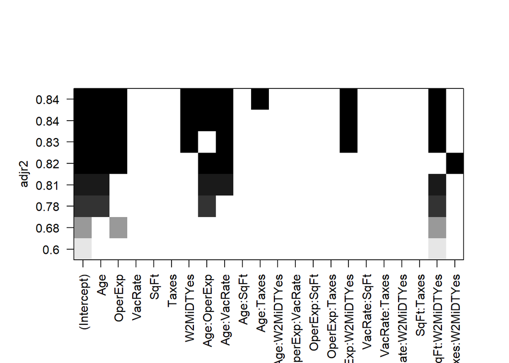

```r
subsets <- regsubsets(RentRate ~ .*., data=comm_prop)
plot(subsets, scale="adjr2")
```

Based on the subsets plot, our variable selection should be Age, OperExp, W2MiDT, Age:OperExp, Age:VacRate, Age:Taxes, OperExp:W2MiDT, and SqFt:W2MiDT.

No VacRate interaction will be used, as it is an unknown variable in our final prediction.

```r
m.sub <- lm(RentRate ~ Age+OperExp+W2MiDT+Age:OperExp+Age:Taxes+OperExp:W2MiDT+SqFt:W2MiDT, data=comm_prop)
summary(m.sub)
```

```
##
## Call:
## lm(formula = RentRate ~ Age + OperExp + W2MiDT + Age:OperExp +
##     Age:Taxes + OperExp:W2MiDT + SqFt:W2MiDT, data = comm_prop)
##
## Residuals:
##      Min       1Q   Median       3Q      Max
## -2.95993 -0.47087  0.00436  0.43161  2.63782
##
## Coefficients:
##                     Estimate Std. Error t value Pr(>|t|)
## (Intercept)        1.243e+01  5.707e-01  21.773  < 2e-16 ***
## Age               -2.451e-01  5.702e-02  -4.298 4.31e-05 ***
## OperExp            2.959e-01  7.125e-02   4.152 7.40e-05 ***
## W2MiDTYes          2.297e+00  7.945e-01   2.891  0.00480 **
## Age:OperExp        1.193e-02  6.790e-03   1.756  0.08238 .
## Age:Taxes          1.049e-02  9.469e-03   1.108  0.27072
## OperExp:W2MiDTYes -2.594e-01  8.085e-02  -3.208  0.00184 **
## W2MiDTNo:SqFt     -6.249e-07  2.120e-06  -0.295  0.76882
## W2MiDTYes:SqFt     9.339e-06  2.186e-06   4.273 4.73e-05 ***
## ---
## Signif. codes:  0 '***' 0.001 '**' 0.01 '*' 0.05 '.' 0.1 ' ' 1
##
## Residual standard error: 0.8125 on 91 degrees of freedom
## Multiple R-squared:  0.8323, Adjusted R-squared:  0.8175
## F-statistic: 56.45 on 8 and 91 DF,  p-value: < 2.2e-16
```

**The results of model m.sub are an Adjusted R-squared value of 0.8175, an F-statistic of 56.45, and a highly significant p-value of <2.2e-16.**

The subset Age:Taxes is not significant, so it can be trimmed from the model.

```r
m.sub1 <- lm(RentRate ~ Age+OperExp+W2MiDT+Age:OperExp+OperExp:W2MiDT+SqFt:W2MiDT, data=comm_prop)
summary(m.sub1)
```

```
##
## Call:
## lm(formula = RentRate ~ Age + OperExp + W2MiDT + Age:OperExp +
##     OperExp:W2MiDT + SqFt:W2MiDT, data = comm_prop)
##
## Residuals:
##      Min       1Q   Median       3Q      Max
## -3.02258 -0.45533  0.02524  0.50456  2.58106
##
## Coefficients:
##                     Estimate Std. Error t value Pr(>|t|)
## (Intercept)        1.247e+01  5.700e-01  21.883  < 2e-16 ***
## Age               -2.551e-01  5.638e-02  -4.525 1.80e-05 ***
## OperExp            2.655e-01  6.584e-02   4.032 0.000114 ***
## W2MiDTYes          1.926e+00  7.214e-01   2.669 0.008981 **
## Age:OperExp        1.577e-02  5.845e-03   2.698 0.008303 **
## OperExp:W2MiDTYes -2.262e-01  7.520e-02  -3.008 0.003389 **
## W2MiDTNo:SqFt      1.306e-06  1.208e-06   1.082 0.282278
## W2MiDTYes:SqFt     1.112e-05  1.482e-06   7.503 3.84e-11 ***
## ---
## Signif. codes:  0 '***' 0.001 '**' 0.01 '*' 0.05 '.' 0.1 ' ' 1
##
## Residual standard error: 0.8135 on 92 degrees of freedom
## Multiple R-squared:   0.83,  Adjusted R-squared:  0.8171
## F-statistic: 64.18 on 7 and 92 DF,  p-value: < 2.2e-16
```

**The Adjusted R-squared value decreased slightly to 0.8171. The F-Statistic increased to 64.18 and the p-value had no change.**

## d) Review and Interpretation of diagnostic plots

```
              **Adjusted R-sqrd   F-Statistic**
          m.1       0.7313            68.35
          m.step    0.8171            64.18
          m.sub1    0.8171            64.18
```

**Models m.step and m.sub1 appear to to have the same values for F-Statistic and Adjusted R-squared and therefore are more appropriate for a predictive model. Further examination will need to be conducted to determine the most appropriate model.**

### Leverage Plot

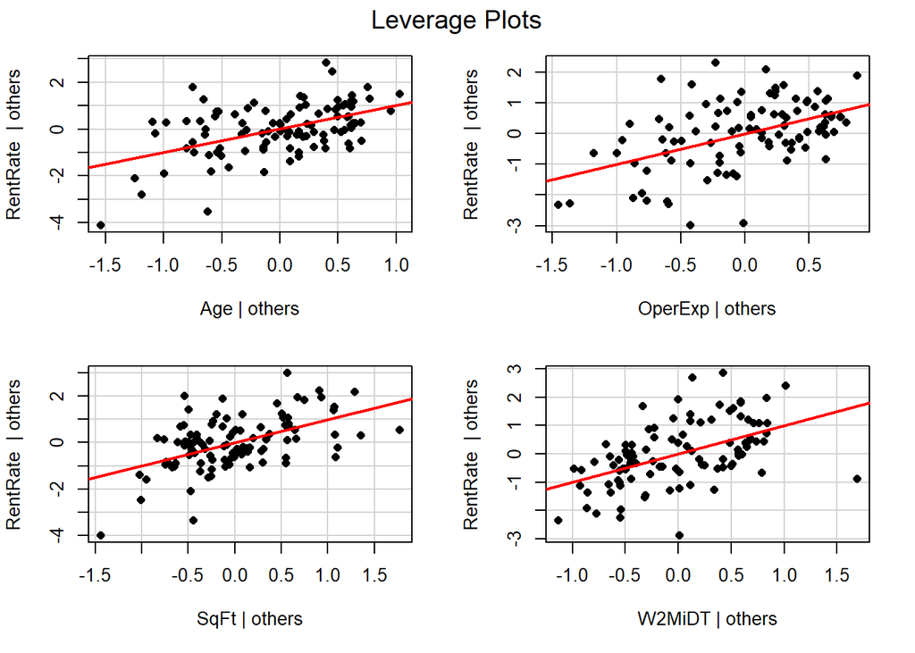

```r
leveragePlots(m.1,pch=16)
```

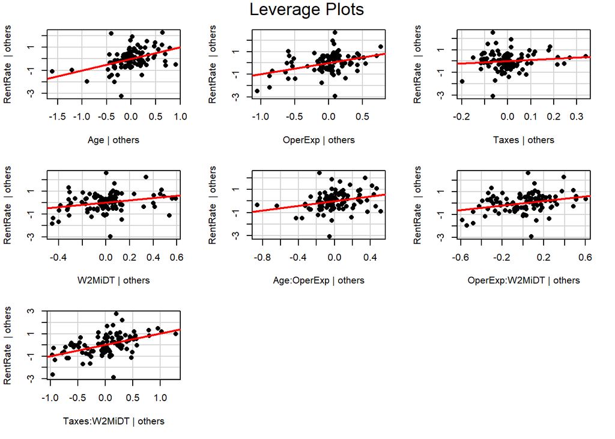

```r
leveragePlots(m.step,pch=16)
```

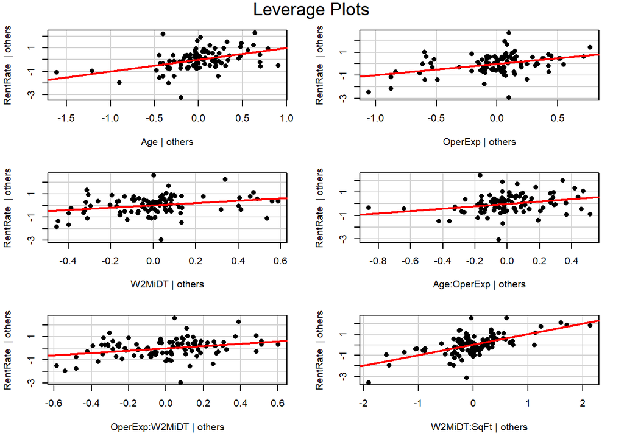

```r
leveragePlots(m.sub1,pch=16)
```

**Observations**: Since the leverage plots for m.1 have slopes farther from y=0, m.1 seems to have the most significant variables compared to the other models.

### Residuals Variance Plot

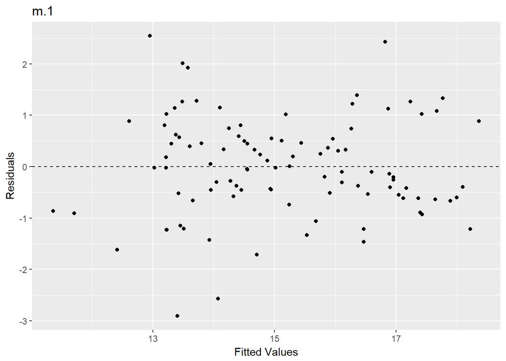

```r
library(ggplot2)
m_df <- fortify(m.1)
ggplot(m_df, aes(x=.fitted, y=.resid)) +
  geom_point() +
  geom_hline(yintercept = 0, linetype = 2) +
  labs(x="Fitted Values", y="Residuals", title="m.1")
```

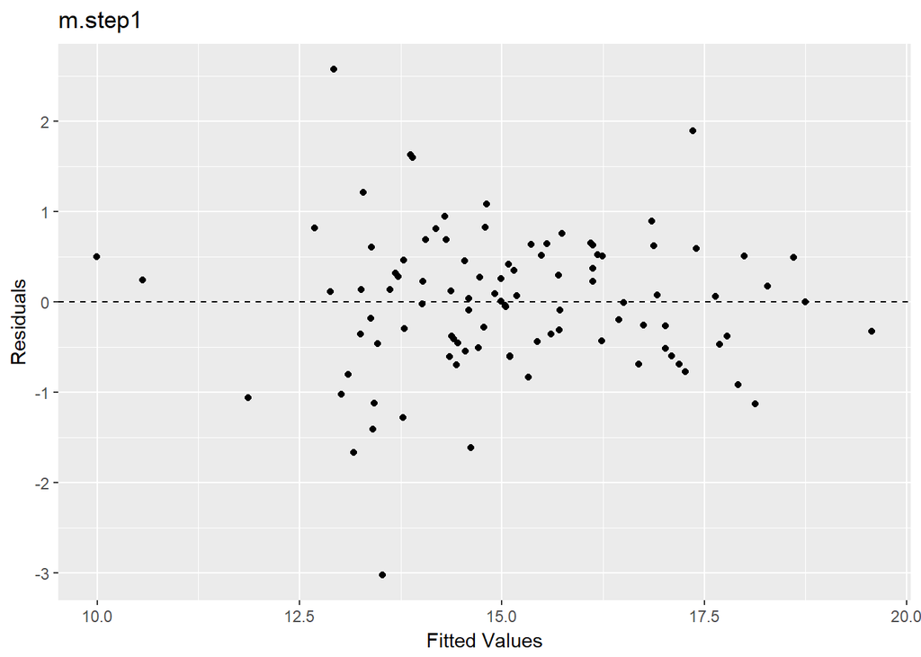

```r
m.step_df <- fortify(m.step)
ggplot(m.step_df, aes(x=.fitted, y=.resid)) +
  geom_point() +
  geom_hline(yintercept = 0, linetype = 2) +
  labs(x="Fitted Values", y="Residuals", title="m.step1")
```

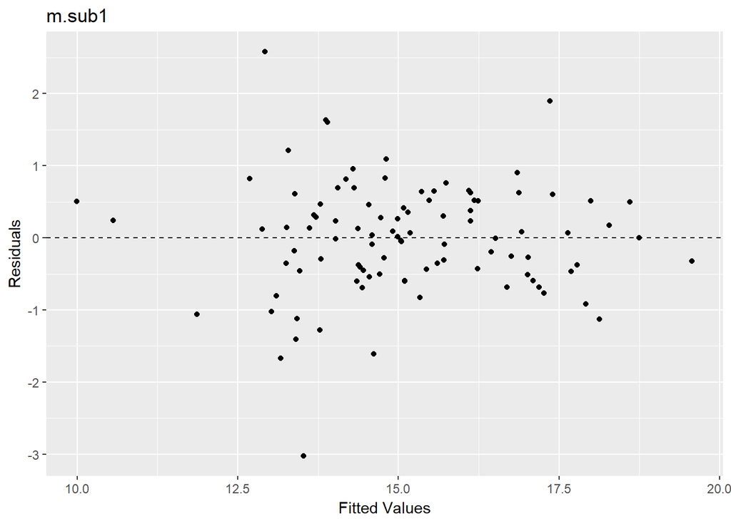

```r
m.sub_df <- fortify(m.sub1)
ggplot(m.sub_df, aes(x=.fitted, y=.resid)) +
  geom_point() +
  geom_hline(yintercept = 0, linetype = 2) +
  labs(x="Fitted Values", y="Residuals", title="m.sub1")
```

**Observations**: Models m.step and m.sub1 both seem to cluster in the middle section of the plot. This suggests non-constant variance.

### Checking for constant variance

```r
car::ncvTest(m.1)
```

```
## Non-constant Variance Score Test
## Variance formula: ~ fitted.values
## Chisquare = 3.279042    Df = 1     p = 0.07016989
```

```r
car::ncvTest(m.step)
```

```
## Non-constant Variance Score Test
## Variance formula: ~ fitted.values
## Chisquare = 8.191176    Df = 1     p = 0.004209462
```

```r
car::ncvTest(m.sub1)
```

```
## Non-constant Variance Score Test
## Variance formula: ~ fitted.values
## Chisquare = 8.186369    Df = 1     p = 0.004220632
```

**Conclusion**: Significantly low p-values for the ncvTest confirm that both the m.step and m.sub1 models have non-constant variance. The m.1 model maintains constant variance, however.

### Visual Representation of Normality of Residuals

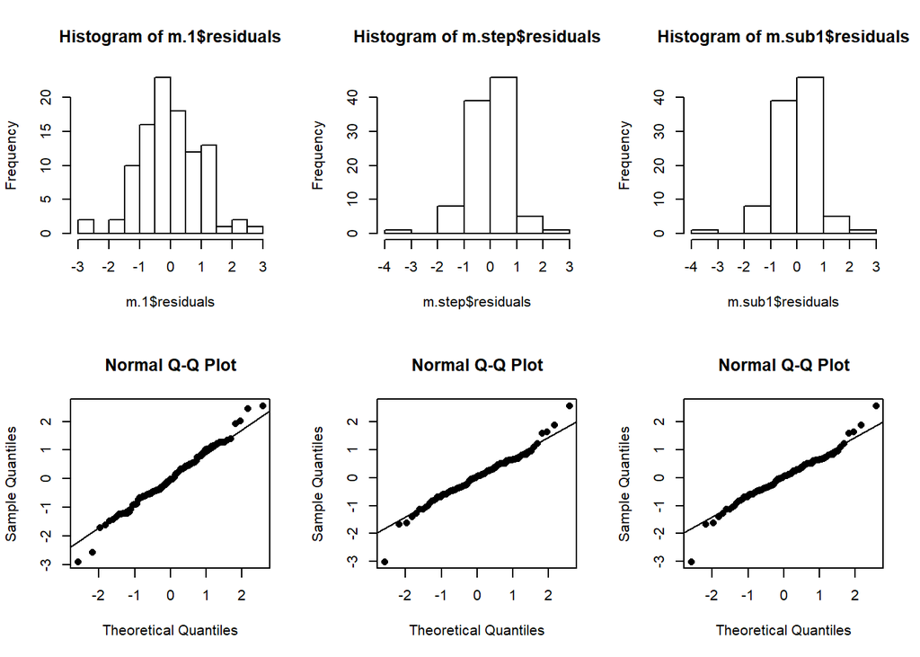

```r
par(mfrow=c(2,3))

hist(m.1$residuals)
hist(m.step$residuals)
hist(m.sub1$residuals)

qqnorm(m.1$residuals, pch=16)
qqline(m.1$residuals)

qqnorm(m.step$residuals, pch=16)
qqline(m.step$residuals)

qqnorm(m.sub1$residuals, pch=16)
qqline(m.sub1$residuals)
```

**Observations**: The residuals appear to be approximately normal.

### Testing Normality of Residuals

```r
shapiro.test(m.1$residuals)
```

```
##
##  Shapiro-Wilk normality test
##
## data:  m.1$residuals
## W = 0.98932, p-value = 0.6099
```

```r
shapiro.test(m.step$residuals)
```

```
##
##  Shapiro-Wilk normality test
##
## data:  m.step$residuals
## W = 0.96971, p-value = 0.021
```

```r
shapiro.test(m.sub1$residuals)
```

```
##
##  Shapiro-Wilk normality test
##
## data:  m.sub1$residuals
## W = 0.96969, p-value = 0.02092
```

**Conclusion**: Significantly low p-values for the Shapiro-Wilk test shows that both the m.step and m.sub1 models are not normally distributed. The m.1 model has approximately normal residuals.

### Test for Multicolinearity

```r
round(vif(m.1),3)
```

```
##     Age OperExp    SqFt  W2MiDT
##   1.460   1.367   1.582   1.527
```

```r
round(vif(m.step),3)
```

```
##            Age        OperExp          Taxes         W2MiDT    Age:OperExp
##         20.061          4.484          2.745         18.120         26.238
## OperExp:W2MiDT   Taxes:W2MiDT
##         23.678          7.480
```

```r
round(vif(m.sub1),3)
```

```
##                  GVIF Df GVIF^(1/(2*Df))
## Age            20.061  1           4.479
## OperExp         4.485  1           2.118
## W2MiDT         18.120  1           4.257
## Age:OperExp    26.238  1           5.122
## OperExp:W2MiDT 23.683  1           4.866
## W2MiDT:SqFt     8.619  2           1.713
```

# 4) Application of the Model

Without further data transformation, due to the non-constant variance and disnormality of the m.step and m.sub1 models, **m.1 is the most appropriate model to use in our prediction.**

**73% of the RentRate’s Variation can be explained by Age, OperExp, SqFt and W2MiDT**

### Application using mathematical function

$$RentRate = 12.05 - 0.104Age + 0.237OperExp + .00000664SqFt + 1.435W2MiDTYes + e$$

```r
12.05 - 0.104*9 + 0.237*13 + .00000664*40 + 1.435*0
```

```
## [1] 14.19527
```

### Application using predict() function (provides interval)

```r
new_obs = data.frame(Age=9, SqFt=40,OperExp=13,W2MiDT="No")
predict(m.1, newdata = new_obs, interval="predict")
```

```
##        fit      lwr      upr
## 1 14.19777 12.16037 16.23517
```

#### **Prediction: We are 95% confidence that the value of RentRate will be between $12,160.37 and $16,235.17. With the combined costs of Operating Expenses and Taxes, $13,540.00, we cannot say with confidence that we will be able to “offset the costs of ownership.” We should sell the building.**

### Further Discussions

Other data points that would potential help the ability to predict Rental Rate are:  
1) More details about the costs that are incorporated in operating expenses so we can consider missing operation costs such as insurance, security, grounds-keeping, etc.  
2) More detailed location  
3) Market dynamics and trends  
4) The domain of the market or consumers